# Differential Gene Expression Analysis

## Part II: QC and setting up for DESeq2

### 1. RNA-seq counts distribution

#### Explore RNA-seq count data

Below is the counts data frame with the genes in the first column and the samples in the following columns. Each cell contains an integer which represents the number of transcripts from a particular gene in that sample.

```r
counts_data %>%
  head() %>%
  kbl(caption = "Count data for each gene obtained from Salmon pseudocounts") %>%
  kable_styling(full_width = FALSE) %>%
  kable_classic_2()
```

Count data for each gene obtained from Salmon pseudocounts

| Gene | Irrel_kd_1 | Irrel_kd_2 | Irrel_kd_3 | Mov10_kd_2 | Mov10_kd_3 | Mov10_oe_1 | Mov10_oe_2 | Mov10_oe_3 |
| --- | --- | --- | --- | --- | --- | --- | --- | --- |
| ENSG00000000003 | 4376 | 3645 | 2968 | 6178 | 3688 | 3343 | 3114 | 2079 |
| ENSG00000000005 | 27 | 29 | 23 | 37 | 13 | 25 | 38 | 22 |
| ENSG00000000419 | 1478 | 1288 | 884 | 2369 | 1340 | 1890 | 1766 | 1271 |
| ENSG00000000457 | 508 | 405 | 357 | 934 | 571 | 646 | 591 | 354 |
| ENSG00000000460 | 1394 | 1164 | 850 | 2172 | 1217 | 1183 | 1139 | 673 |
| ENSG00000000938 | 1 | 1 | 0 | 2 | 0 | 0 | 0 | 0 |

We can plot the distribution of counts for each sample using a histogram, which will demonstrate the common features of RNA-seq data: there are generally low counts for a large proportion of the genes, and a large tail in the distribution as there is no upper limit to gene expression.

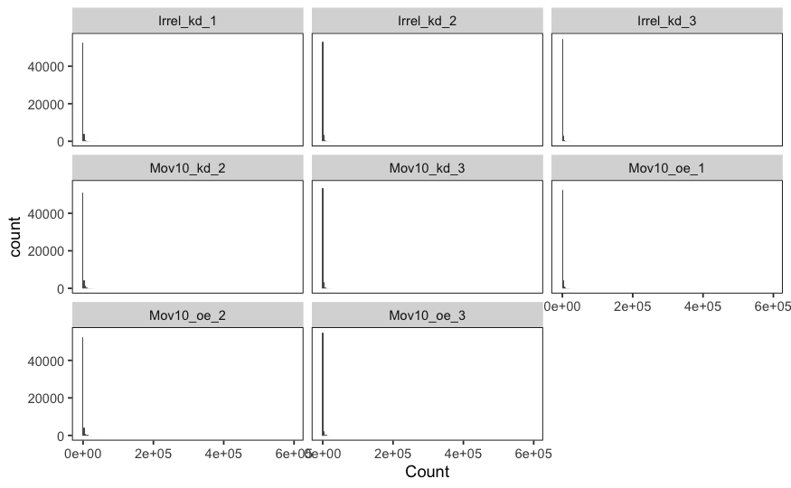

```r
# Generate a histogram for each sample
counts_data %>%
  pivot_longer(cols = !Gene,
               names_to = "Sample",
               values_to = "Count") %>%
  ggplot(aes(Count)) +
  geom_histogram(stat = "bin",
                 bins = 200) +
  facet_wrap(~ Sample) +
  my_theme
```

#### Modeling count data

- Count data can be modeled either with the binomial distribution (e.g., modeling the number of times you would expect to see heads in a series of coin tosses) or the Poisson distribution. The latter if often used when the number of trials is very large, but assumes that the mean and the variance are equal.
- To evaluate whether we meet this assumption, we’ll use the three MOV10 over-expression replicates and generate vectors for the mean counts for each gene and the variance.
- Then, we can visualize the relationship between the mean and variance in a scatterplot.

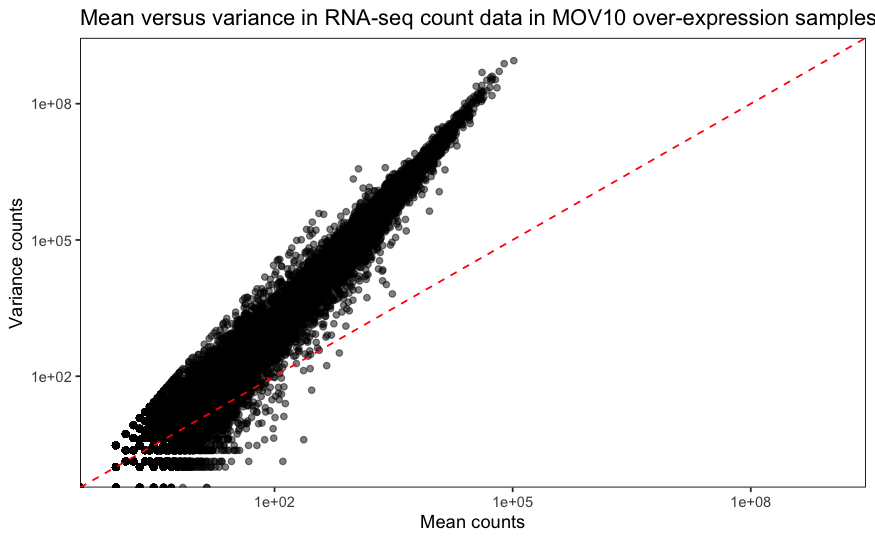

```r
# Calculate mean and variance for each gene in the three Mov10 overexpression samples
counts_data_stats <- counts_data %>%
  select(Gene, contains("Mov10_oe")) %>%
  mutate(Mean_count = apply(select(., contains("Mov10_oe")), 1, mean),
         Variance = apply(select(., contains("Mov10_oe")), 1, var))

# Plot the mean and variance and add a continuous slope line where mean = variance
counts_data_stats %>%
  ggplot(aes(Mean_count, Variance)) +
  geom_point(alpha = 0.5) +
  scale_x_log10(limits = c(1, 1e9)) +
  scale_y_log10(limits = c(1, 1e9)) +
  geom_abline(intercept = 0,
              slope = 1,
              linetype = "dashed",
              color = "red") +
  my_theme +
  labs(x = "Mean counts",
       y = "Variance counts",
       title = "Mean versus variance in RNA-seq count data in MOV10 over-expression samples")
```

- This plot reveals that the mean and variance are not equal- if they were, the points would be right along the dashed red line.
- Instead, we can see that for genes with higher mean counts, the variance is higher than the mean (i.e., the points are above the dashed line).
- The genes with lower mean counts also display heteroscedasticity, or the tendency for low mean counts to have high variability in the variance estimates.

#### An alternative: the negative binomial distribution

- [This blogpost](http://bridgeslab.sph.umich.edu/posts/why-do-we-use-the-negative-binomial-distribution-for-rnaseq) provides a brief explanation for using the negative binomial distribution to model count data in RNA-seq data sets.
- In summary, RNA-seq data cannot be normally distributed, because we cannot have negative counts, or fractions of counts; all of the counts must be positive whole numbers (i.e., positive integers).
- Because the Poisson distribution assumes the mean and variance are equal, this is not appropriate for RNA-seq data sets where the number of replicates is relatively small and thus, we cannot accurately estimate variance.
- The negative binomial distribution is an appropriate alternative, as this probability distribution doesn’t assume equal mean and variance for count data.
- However, if we had enough replicates (which is often unfeasible for RNA-seq experiments), we may be able to use the Poisson if the variance is reduced such that the assumption of equal mean and variance is satisfied.

#### Replicates and variability

- Recall, biological replicates come from the same biological condition but different sources (e.g., DNA samples taken from mice raised in the same experimental conditions).
- One of the challenges in differential gene expression analysis is identifying and correcting for unknown sources of biological (e.g., mice with different genetic backgrounds) or technical variation (e.g., different lot numbers of reagents, etc.).
- HBC recommends running running experiments in triplicate (e.g., three replicates for a experimental group and three replicates for a control group).
- However, more replicates are generally always better because we can get more precise estimates of the mean and variance, and thus, better detect meaningful differences between groups.
- The authors also include a figure from a study showing the increase in the number of differentially expressed genes as a function of the number of replicates included in a study, more so than the sequencing depth.

#### Differential Expression with DESeq2

- We will be using the DESeq2 package for differential gene expression analysis, which employs the negative binomial distribution to model counts from RNA-seq data.

### 2. Count normalization

#### Normalization

- Normalization involves adjusting the counts for each gene and sample to account for the variability associated with factors that aren’t related to the experimental differences between groups, for example.
- There are several factors which need to be considered during the normalization step:
  - **Sequencing depth:** we need to account for differences in the number of reads which map to each gene (sequencing depth), as we may observe differences in counts that are simply due to differences in sequencing depth.
  - **Gene length:** we also need account for differences in counts between different genes in the same sample, because one gene may be longer than the other, and longer genes have a biased increase in the number of reads which map to them relative to shorter genes.
  - **RNA composition:** some genes may have large differences in counts between two samples, and because of that, may dominate the differential expression signal and drown out lower expressed genes that are differentially expressed if they are not normalized to adjust for these large differences.

#### Normalization methods

- There are different normalization methods used, most of which account for either sequencing depth or a combination of sequencing depth and gene length, but are not suitable for evaluating between-sample comparisons or differential gene expression analyses (e.g., transcripts per million).
- The reason we can’t use some normalization methods like reads per kilobase per million mapped reads (RPKM) is because the RPKM-normalized counts between samples could be different, which doesn’t allow us to evaluate differences in gene expression.

#### DESeq2-normalized counts: median of ratios method

- Differences in sequencing depth (differences in the number of reads mapped to the same gene in two different samples) and the RNA composition need to be accounted for in the normalization method.
- DESeq2 uses the median of ratios method to normalize counts, which involves several steps:
1. Create a pseudo-reference sample by calculating the row-wise geometric mean.
- The geometric mean is calculated by taking the square root of the product of counts row-wise, and is used in situations when two counts may be very different and is less sensitive to influence from the larger number.
2. Calculate the ratio of the count for each sample to the pseudo-reference sample.
3. Calculate the normalization factor for each sample by taking the median of all of the ratios for each sample to the pseudo-reference across all genes.
- The key concept behind this approach is that it assumes that not all of the genes are differentially expressed, so it successfully accounts for the sequencing depth and RNA composition because it is not sensitive to larger outlier genes.
4. Calculate the normalized counts for each gene in each sample by dividing the raw counts by the per-sample normalization factor.
- Note, the normalized counts will not necessasrily be whole numbers.

#### Count normalization of Mov10 dataset using DESeq2

- First, we need to make sure that the counts data and the metadata have matching information.

```r
# Match the metadata and counts data files
all(colnames(txi$counts) %in% counts_metadata$sample_name) # TRUE
```

```
[1] TRUE
```

```r
all(colnames(txi$counts) == counts_metadata$sample_name) # TRUE
```

```
[1] TRUE
```

#### Exercises

- If the sample names in the counts matrix and the metadata file are the same, but they are in a different order, how can we re-order them to satisfy this requirement?

```r
# Test vectors
a <- c("apple", "banana", "orange")
b <- c("banana", "apple", "orange")

# Test conditions
all(a %in% b) # TRUE
all(a == b) # FALSE- because they are in a different order

# Try rearranging with match using bracket subsetting
c <- a[match(a, b)]

# Test again
all(c %in% b) # TRUE
all(c == b) # TRUE

# Reverse the sample name order
counts_metadata_testing <- counts_metadata %>%
  arrange(desc(sample_name))

# Test again with the counts matrix
all(colnames(txi$counts) %in% counts_metadata_testing$sample_name) # TRUE
all(colnames(txi$counts) == counts_metadata_testing$sample_name) # FALSE

# Apply the line of code to fix the names
new_arrangement <- counts_metadata_testing$sample_name[match(counts_metadata_testing$sample_name, colnames(txi$counts))]

# Re-arrange the counts_metadata_testing data frame with the new arragement
counts_metadata_testing <- counts_metadata_testing %>%
  arrange(match(.$sample_name, new_arrangement))

# Test one last time
all(colnames(txi$counts) %in% counts_metadata_testing$sample_name) # TRUE
all(colnames(txi$counts) == counts_metadata_testing$sample_name) # TRUE
```

- To create a DESeq2 object, we need both the count matrix and metadata (which is why they need to be in the same order) as well as a design formula, which controls how the package evaluates gene expression across different groups (e.g., control, knockdown, and over-expression).

```r
# Convert the characters in the metadata to factors
counts_metadata <- counts_metadata %>%
  mutate(across(where(is.character), as.factor))

# Create the DESeq2 object by specifying the metadata as the colData and the sample type as the design
dds <- DESeqDataSetFromTximport(txi, colData = counts_metadata, design = ~sample_type)
```

```
using just counts from tximport
```

- The next step is to perform the median of ratios normalization step using the `estimateSizeFactors()` function.

```r
# Normalize counts using median of ratios method
dds <- estimateSizeFactors(dds)

# View the sample-specific normalization factors using the sizeFactors() function
data.frame(norm_factor = sizeFactors(dds)) %>%
  rownames_to_column("sample") %>%
  kbl(caption = "Per-sample median of ratios normalization factors calculated with DESeq2") %>%
  kable_styling(bootstrap_options = "striped",
                full_width = FALSE) %>%
  kable_classic_2()
```

Per-sample median of ratios normalization factors calculated with DESeq2

| sample | norm_factor |
| --- | --- |
| Irrel_kd_1 | 1.1150371 |
| Irrel_kd_2 | 0.9606366 |
| Irrel_kd_3 | 0.7493552 |
| Mov10_kd_2 | 1.5634128 |
| Mov10_kd_3 | 0.9359082 |
| Mov10_oe_1 | 1.2257749 |
| Mov10_oe_2 | 1.1406863 |
| Mov10_oe_3 | 0.6541689 |

- Now to obtain the normalized size factors, we use the `counts()` function with the argument `normalized = TRUE`.

```r
# Extract the normalized counts from the DESeq2 data set
normalized_counts <- counts(dds, normalized = TRUE)

# Save this as a text file for later
normalized_counts %>%
  data.frame() %>%
  rownames_to_column("Gene") %>%
  write_csv(., "./data/normalized_counts.csv")

# View the first few normalized counts to see how they've changed from the original counts
t1 <- counts(dds) %>%
  head() %>%
  data.frame() %>%
  rownames_to_column("Gene")

t2 <- normalized_counts %>%
  head() %>%
  data.frame() %>%
  rownames_to_column("Gene") %>%
  mutate(across(where(is.numeric), ~round(.x, digits = 2)))

kable(list(t1 %>% select(., Gene, contains("Mov10_oe")),
           t2 %>% select(., Gene, contains("Mov10_oe"))),
      caption = "Raw (left) versus normalized (right, rounded to two digits) gene counts from DESeq2",
      booktabs = TRUE) %>%
  kable_styling(full_width = FALSE,
                bootstrap_options = "striped") %>%
  kable_classic_2()
```

Raw (left) versus normalized (right, rounded to two digits) gene counts from DESeq2

| Gene | Mov10_oe_1 | Mov10_oe_2 | Mov10_oe_3 |
| --- | --- | --- | --- |
| ENSG00000000003 | 3343 | 3114 | 2079 |
| ENSG00000000005 | 25 | 38 | 22 |
| ENSG00000000419 | 1890 | 1766 | 1271 |
| ENSG00000000457 | 646 | 591 | 354 |
| ENSG00000000460 | 1183 | 1139 | 673 |
| ENSG00000000938 | 0 | 0 | 0 |

| Gene | Mov10_oe_1 | Mov10_oe_2 | Mov10_oe_3 |
| --- | --- | --- | --- |
| ENSG00000000003 | 2727.25 | 2729.94 | 3178.08 |
| ENSG00000000005 | 20.40 | 33.31 | 33.63 |
| ENSG00000000419 | 1541.88 | 1548.19 | 1942.92 |
| ENSG00000000457 | 527.01 | 518.11 | 541.14 |
| ENSG00000000460 | 965.10 | 998.52 | 1028.79 |
| ENSG00000000938 | 0.00 | 0.00 | 0.00 |

### 3. Sample-level QC

#### Sample-level QC

- The basics of QC for RNA-seq data is to evaluate our data at the sample level and at the gene level.
- For example, one of the questions we want to know is how samples cluster together or appear more similar, and if this matches what we would expect based on our background knowledge.
- For sample-level QC, we really want to know how similar the replicates are to each other, mostly to confirm that the experimental condition (e.g., treatment) is the major source of variation in the data, not sample-to-sample variability.
- Instead of just using the normalized counts, we’ll use the regularized log-transformed normalized counts, which helps to avoid the high variability in variance estimates in genes with low counts (see above sections) by shrinking those low read counts toward the per-gene average across all samples.
- The genes with high counts will have transformed values similar to those obtained using the log2 transformation.

#### Principal components analysis (PCA)

- PCA is an powerful tool for dimensionality reduction and in this context, if replicates have similar expression profiles across genes, they will cluster together in PCA space relative to samples from a different treatment condition with different expression profiles.
- In some cases, as in the example in the tutorial, the treatment is not the only source of variation in the data- in fact, other factors like sex may contribute a larger amount to the overall variability in the data instead of the treatment.
- However, in some cases, it may be possible to account for these factors in the modeling step such we can still parse out the differentially expressed genes associated with the treatment.

#### Hierarchical clustering heatmap

- The heatmap shows the correlation of gene expression for all pairwise combinations of samples in the data and the different axes display substructure in the data.
- In the example in the tutorial, we would expect that the sample replicates would have a high correlation in their gene expression profiles, and would thus cluster together in the heatmap.

#### MOV10 quality assessment and exploratory analysis using DESeq2

- The first step to quality assessment with PCA and hierarchical clustering is to transform the normalized counts using the regularized-log2 transformation to account for the heteroskedastic nature of the data (i.e., variance in the response is not equal across the range of the predictor values) and normalize by library size.

```r
# Transform the normalized counts using rlog2 transformation
# Importantly, we need to use the `blind=TRUE` argument so the transformation is done without taking into account the sample groups
rld <- rlog(dds, blind = TRUE)
```

#### PCA for the MOV10 dataset

- The `DESeq2::plotPCA()` function plots the PCA using `ggplot2` under the hood and takes the `rlog()` transformed object directly as input.

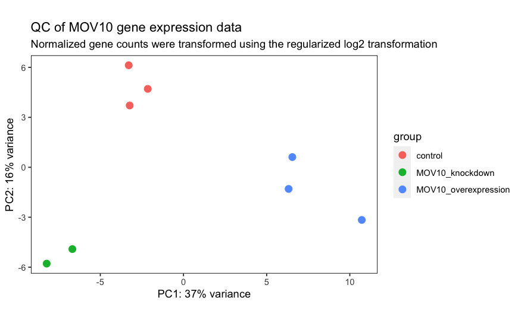

```r
# Generate a PCA plot for the MOV10 data
plotPCA(rld, intgroup = "sample_type") +
  labs(title = "QC of MOV10 gene expression data",
       subtitle = "Normalized gene counts were transformed using the regularized log2 transformation") +
  my_theme
```

#### Exercise

1. *What does the above plot tell you about the similarity of samples?*

The plot indicates that each biological replicate is more similar to one another than to other biological replicates.

2. *Does it fit the expectation from the experimental design?*

The experimental design includes three biological replicates for each group (except for one group): three control replicates, two MOV10 knockdown replicates, and three MOV10 over-expression replicates. From this design, we could expect all of the controls to group together, all of the knockdowns to group together, and all of the over-expression replicates to group together. Indeed, this is exactly what we see.

3. *What do you think the % variance information (in the axes titles) tell you about the data in the context of the PCA?*

The `% variance` on each axis describes the variation in the gene count data explained on each principal component axis. The strategy behind PCA is to reduce dimensionality and explain the total variation in the data set with as few variables as possible. In the context of the experiment, the first principal component separates the MOV10 treatments: the knockdowns and the over-expression replicates. The second principal component separates the MOV10 treatments from the control treatmet with normal MOV10 expression.

#### Additional PCA QC

- While the `plotPCA()` function is a powerful tool to quickly perform quality control on RNA-seq data, it has two caveats: it will only plot the top 500 most variable genes (which likely explains more than enough variation anyway), and it will only plot the first two principal components. For additional functionality to plot different principal components, we can use the `prcomp()` function. This will also allow us to extract useful information like the loadings (stored in the `rotation` slot), or the “weight” of different genes in explaining variation along a PCA axis.
- Importantly, the matrix gives the observations as columns and the features (i.e., genes) as rows, but we need this to be flipped so the observations are in rows and the variables in columns. See this stacks exchange [post](https://stats.stackexchange.com/questions/248825/why-do-we-need-to-take-the-transpose-of-the-data-for-pca) for more details.

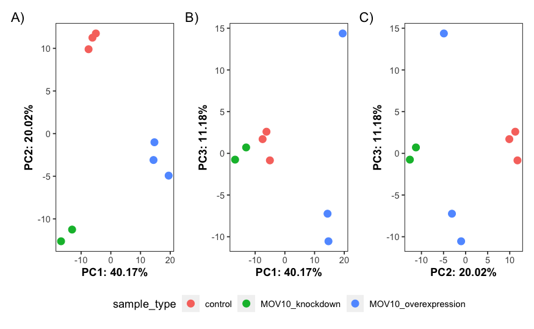

```r
# Extract the regularized log-transformed counts into a matrix
rld_pca <- assay(rld) %>%
  t() %>%
  prcomp()

# Extract summary information
summary_df <- summary(rld_pca) %>%
  pluck("importance") %>%
  data.frame() %>%
  rownames_to_column("Term") %>%
  filter(Term == "Proportion of Variance") %>%
  mutate(across(where(is.numeric), function(x) round(x * 100, digits = 2)))

# Import metadata
metadata <- read_csv("./metadata/counts_metadata.csv")
# Extract coordinates from PCA into a data frame and bind with metadata
pca_df <- cbind(metadata, rld_pca$x)

# Create plotting function
plot_pca <- function(df, axis1, axis2) {
  df %>%
    ggplot(aes_string(paste("PC", axis1, sep = ""),
               paste("PC", axis2, sep = ""))) +
    geom_point(aes(color = sample_type),
               size = 3) +
    labs(x = paste("PC", axis1, ": ", eval(summary_df %>% dplyr::select(paste("PC", axis1, sep = ""))), "%", sep = ""),
         y = paste("PC", axis2, ": ", eval(summary_df %>% dplyr::select(paste("PC", axis2, sep = ""))), "%", sep = "")) +
    my_theme +
    theme(
      axis.title.x = element_text(face = "bold"),
      axis.title.y = element_text(face = "bold")
    )
}

plot_pca(pca_df, 1, 2) +
  plot_pca(pca_df, 1, 3) +
  plot_pca(pca_df, 2, 3) +
  plot_layout(guides = "collect") +
  plot_annotation(tag_levels = "A", tag_suffix = ")") &
  theme(legend.position = "bottom")
```

- We can see additional patterns arise when we plot different PC axes. Notably, when we plot PC1 and PC3, the MOV10 knockdown and control samples cluster together. Interestingly, there is some odd behavior with one of the MOV10 over-expression samples on PC3 that may need to be investigated further.ß

#### Hierarchical Clustering for the MOV10 dataset

- To construct a heatmap, we need to use the `SummarizedExperiment::assay()` function to extract a matrix from the `DESeq2` object, then calculate the correlation using the `cor()` base R function to calculate all of the pairwise correlations for all samples. We’ll use the `metadata` table to annotate the heatmap.

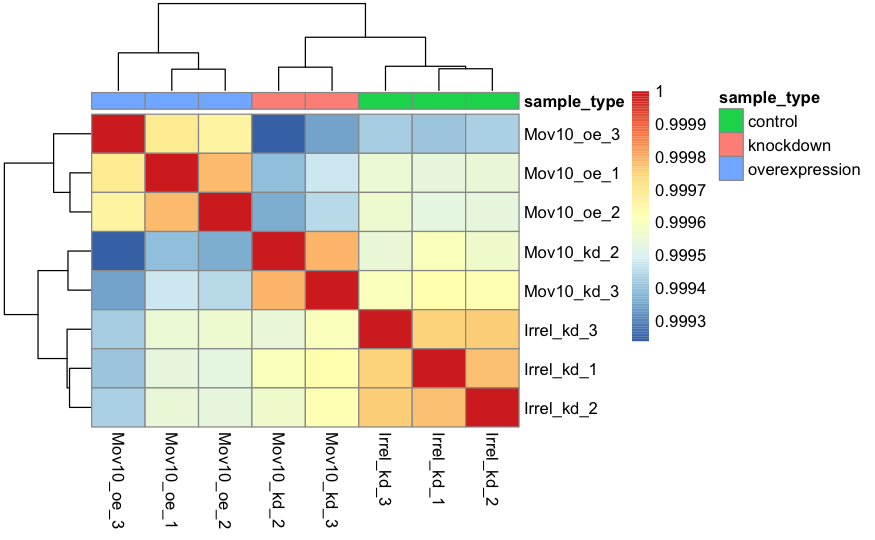

```r
# Extract the matrix from the DESeq2 object
assay_mat <- assay(rld) %>%
  cor()

# Create new metadata object
metadata <- data.frame(sample_type = rep(c("control", "knockdown", "overexpression"),
                                    c(3, 2, 3)))
row.names(metadata) <- colnames(assay_mat)

# Plot the heatmap
pheatmap(assay_mat, annotation = metadata)
```

- Overall, we see high correlations between samples of the same type, indicating that this dataset won’t likely lead to any issues when identifying differentially expressed genes.

### 4. Design formulas

- DESeq2 models counts of genes using the negative binomial distribution and generalized linear models (GMLs).
- It’s important to note that there are two types of distributions for modeling count data: the Poisson distribution, and the negative binomial distribution. The former assumes the variance and mean are equal, and is thus only controlled by a single parameter, lambda; the latter does not make this assumption, and is more flexible for dealing with gene count data.
- This is critical, because often, the number of technical replicates is quite low for RNA-seq experiments, making it challenging to accurately estimate variance.
- At a high-level overview, however, what we’re aiming to do with DESeq2 is statistically evaluate if the mean expression of different genes across sample groups is different. The `DESeq()` function estimates the size factors and dispersion of each gene (the dispersion is a metric of the spread of the data distribution), and fits a negative binomial generalized linear model. The Wald test is conducted to test for statistical significance of each gene.
- The design formula allows us to define which sources of variation we want to control for in the model that could be confounding factors (e.g., sex, or age), and which is the factor of interest (e.g., treatment).
- In the design formula, all factors that we want to account for in the metadata should be included if they are major sources of variation, and the last factor will be the condition of interest.

#### Exercises

1. *Suppose you wanted to study the expression differences between the two age groups in the metadata shown in the tutorial, and major sources of varition were `sex` and `treatment`, how would the design formula be written?*
- The design formula would be written as: `design <- ~ sex + treatment`.
2. *Based on our Mov10 metadata data frame, which factors should we include in our design formula?*
- Based on the previously conducted QC PCA and hierarchical clustering analyses, there are no additional terms in the metadata data frame that we should include in the design formula other than `sample_type`.
- Thus, our design formula would written as: `design <- ~ sample_type`.
3. *What would you do if you wanted to include a factor in your design formula that is not in your metadata?*
- If you wanted to do this, you would need to create a new column in your metadata data frame and ensure that it matches the factor in the design formula.

#### MOV10 DE Analysis

- To run the DESeq analysis, we just need to create a new `DEseq2Dataset` object with the raw counts, and then run the `DESeq()` function.

```r
# Create a new DESeq2Dataset object
dds <- DESeqDataSetFromTximport(txi, colData = metadata, design = ~ sample_type)
```

```
some variables in design formula are characters, converting to factorsusing just counts from tximport
```

```r
# Run the analysis
dds <- DESeq(dds)
```

#### Exercise

Below are the various design formulas that would be used to test for different effects while controlling for various factors.

- Test the effect of `treatment`: `design <- ~ treatment`.
- Test for the effect of genotype, while regressing out the variation due to `treatment`: `design <- ~ treatment + genotype.`
- Test for the effect of `genotype` on the `treatment` effects: `design <- ~ genotype + treatment + genotype:treatment`.

### 5. Hypothesis testing and multiple testing correction

- The next part of the analysis involves fitting the count data to the negative binomial, which models the raw counts of the gene as a function of the mean counts (normalized counts scaled by the sample-specific normalization factor; see above section of the median of ratios), and one dispersion term (RNA-seq data exhibit over-dispersion, or variance greater than the mean).
- The negative binomial model is part of the Generalized Linear Model (GLM) family, whic generalizes linear regression models to allow for error distributions other than the normal distribution, and modeling the response variable as a function of the predictors using a link function.

#### Hypothesis Testing

- The resulting output from the `DESeq2` model is log2 fold changes.
- The Wald test is used for hypothesis testing, the null hypothesis being the log2 fold change is 0, the alternative hypothesis being the log2 fold change is not zero.
- The Wald test takes the log2 fold change and divides it by the associated standard error to create a z-statistic, which is then compared to a standard normal distribution (i.e., normal distribution with a mean of 0 and standard deviation of 1) to calculate a p-value.
- Importantly, the Wald test is used when we are comparing two classes (e.g., treatment versus control), but the likelihood ration test can also be used as a hypothesis test when comparing more than two classes.
- The likelihood ration test extends the capability of the hypothesis test by fitting two models per gene (while the Wald test fits one model per gene); a reduced model with the main factor in the design formula removed; and a full model, with the main factor in the design formula included. In this case, we are comparing whether there is a significant difference in the fit between the full model and the reduced model.

#### Exercise

1. An appropriate hypothesis test to evaluate differences in gene expression across developmental stages would be the likelihood ratio test, since the ultimate aim is to compare gene expression across multiple time points.
2. Below is the line of code to create the `dds` object. Here, we would be primarily interested in understanding the interaction of sex and developmental stage on gene expression differences.

```r
# Code to create dds object
DESeqDataSetFromTximport(txi, colData,
                         design = "~ sex + dev_stage + sex:dev_stage")
```

```r
# Code to run DESeq
DESeq(mouse_data, test = "LRT",
      reduced = ~ sex + dev_stage)
```

4. In this case, we could subset the `dds` object and perform a Wald test only comparing these two timepoints.

## Part III: DESeq2

### 2. Wald test results

### 3. Summarizing results and extracting significant gene lists

### 4. Visualization

### 5. Likelihood Ratio Test Results

### 6. Time Course Analysis

## Part IV: Functional Analysis

### 1. Gene Annotation

### 2. Functional Analysis I: Over-Representation Analysis

### 3. Functional Analysis II: Functional Class Scoring/GSEA